# Monte Carlo Simultions and Bootstrap

Yen-Chi Chen

5/20/2017

# Monte Carlo Simulations

Assume in a dataset, we observe $n$ values, denoted as $X_1,\cdots,X_n$. For simplicity, we assume that these observations are an IID (indenpendently, identically distributed) random sample from an unknown distribution function $F(x)$.

Because these $n$ values are random, any statistic derived from them will also be random. For instance, let $S_{\sf med}$ be the median of these $n$ values (sample median). The value of the median will be determined by these $n$ observations. Because these observations are a random sample from the distribution $F$, the median will also be random, and it will have its own distribution (also depends on $F$ but through a more complicated way)!

Assume the distirbution is something we know, say a standard Normal distribution $N(0,1)$, and the sample size $n = 100$. What will the distribution of the sample median be?

We can find this out using the Monte Carlo Simulation approach. First we draw a random sample using R and compute the sample median:

```
## [1] -0.0603714
```

This gives us one realization of the median. However, every time we apply the same program, we obtain a different value of the sample median because of a different sets of points we are having.

One way to investigate the distribution of sample median is to repeat the above procedure many times and keep track of the sample median of each sample we generate.

```
## [1]  0.16057384 -0.01517983 -0.13654199  0.06895646 -0.16498875 -0.17596825
```

The object `many_median` contains the $10000$ realizations of the sample median. To see its distribution, we can simply use the histogram:

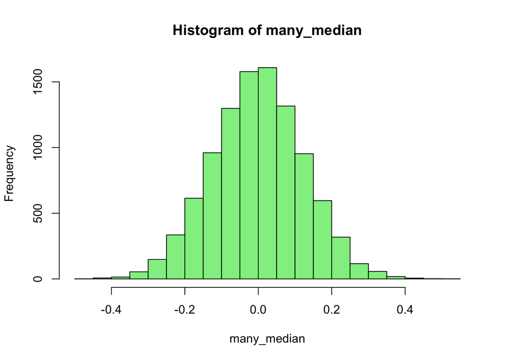

Surprisingly, the sample median also follows roughly a Normal distribution (actually you can prove this fact but it requires some advanced probability techniques).

The above method we are using is call *Monte Carlo Simulation*–to investigate the distribution of something, instead of using mathematics to derive it, we use computer experiments to obtain an approximated answer to the problem. The number of repition $N$ is sometimes called the size of Monte Carlo Simulation and it controls the error of the simulation (this type of error is called Monte Carlo errors). Similar to the sample size, a large repition $N$ we are using, a smaller Monte Carlo error we have.

Not only the median, we can also use the Monte Carlo Simluation to investigate other statistic, for instance, the interquartile range (IQR).

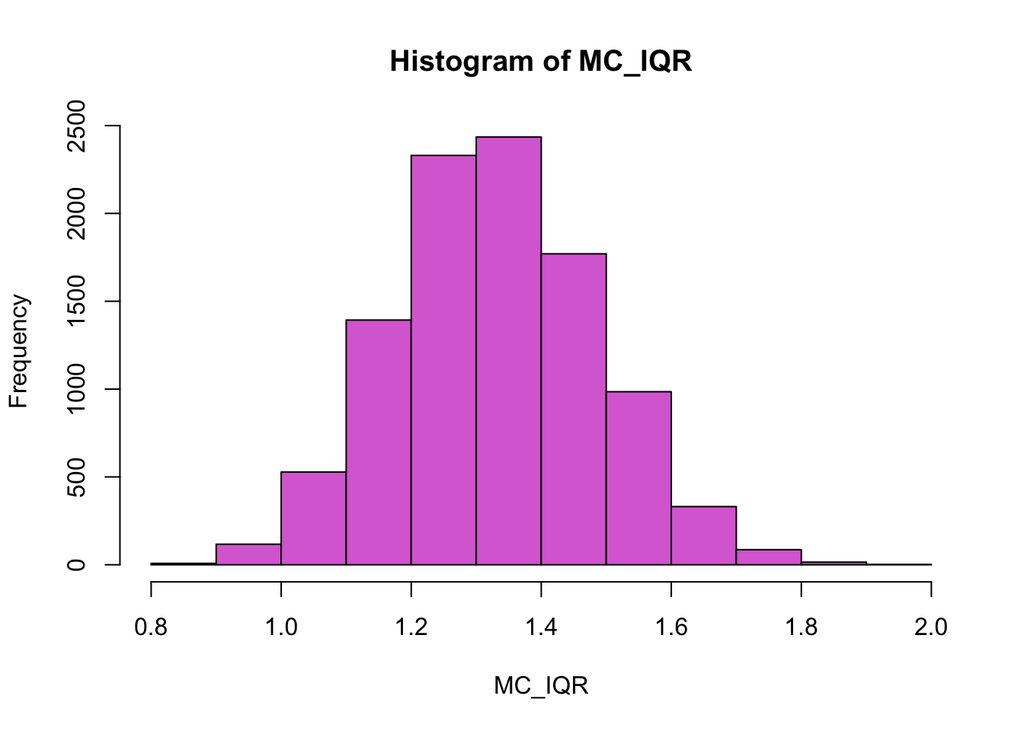

The distribution of IQR also follows a Normal distribution! Actually, many statistics you are familiar with follow a Normal distribution. But of course there will be some exceptions (for instance, the maximum value and the minimum value will not follow a Normal distribution in general).

If now we want to investigate the distribution of sample median/IQR of a different size of sample and from a different distribution, we can simply change the sample size $100$ to another value and the function `rnorm()` to others. Here is an example of the sample median and IQR from a size $500$ random sample from a distribution $N(2,4)$:

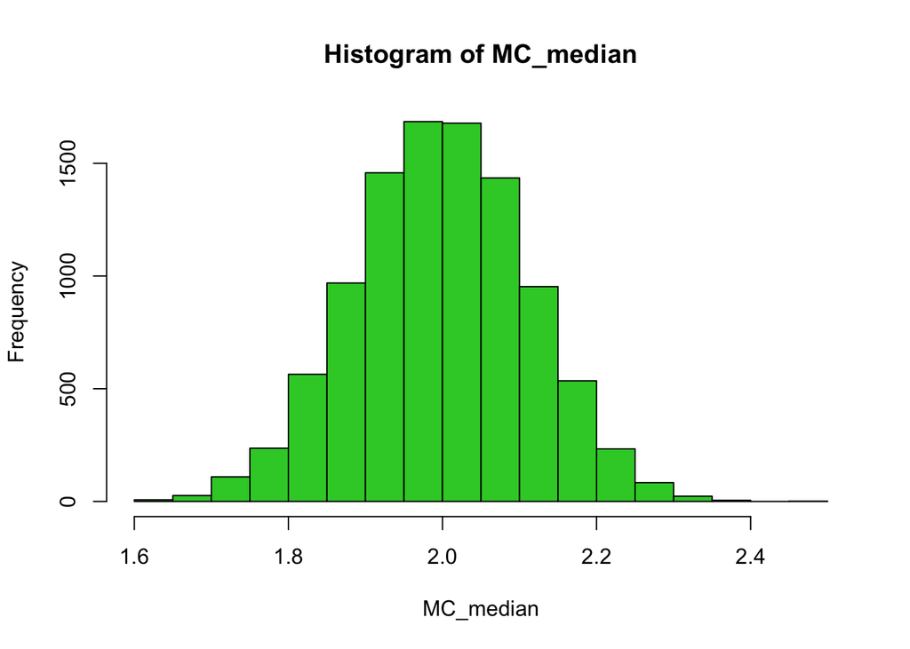

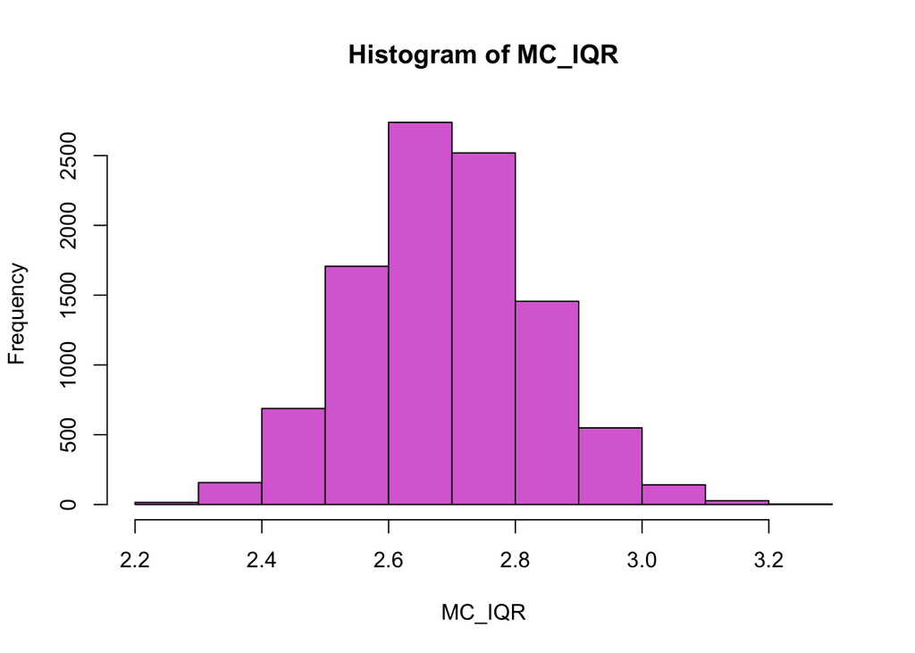

Because these statistics have a distribution, we can also measure their spreads by the “variance”. Note that here we are looking for the “variance” of “sample median” and the “variance” of “sample IQR”, not the variance of the original sample.

```
## [1] 0.01251085
```

```
## [1] 0.01990215
```

The Monte Carlo Simulation can also be used to estimate a “probability”. Here is one example. Let $X$ be a random variable from $N(2,4)$ and $Y$ is a random variable (independent from $X$) from a uniform distribution over [1,5]. What is the probability that $X<Y$? Namely, what is the value $P(X<Y)$? Mathematically, we know that there is an answer. But it may not be easily computed. Here is how we can use the Monte Carlo Simulation to compute it:

```
## [1] FALSE  TRUE  TRUE FALSE FALSE FALSE
```

```
## [1] 0.6642
```

In the Monte Carlo simulation, we keep generating realizations of $X$ and $Y$ and try to compare if $X<Y$. Now let $X_i,Y_i$ be a pair of value that are generated. What is the outcome if we type $X_i<Y_i$ in R? It will be a logical value such that if $X_i<Y_i$, the value is `T` otherwise the value is `F`. If we treat the logical value as numerics, then the outcome take value $1$ if $X_i<Y_i$ otherwise it takes value $0$. Let the outcome be $D_i$. Because $X_i,Y_i$ are random, $D_i$ is also a random number. But $D_i$ only takes value $0$ and $1$–this implies that $D_i$ is a Bernoulli random variable! For a Bernoulli random variable, there is a probability parameter determining the chance of generating value $1$. What is that probability for $D_i$? Recall that $D_i=1$ if and only if $X_i<Y_i$. Thus $P(D_i=1) = P(X_i<Y_i)$ is the probability we want to estimate!

As a result, the logical vector `cf_value` is actually just $n$ realizations of a Bernoulli distribution with the probability parameter $P(X<Y)$! So the average value of the vector `cf_value` is just the proportion of value `T` (or the numeric value $1$) being generated (sometimes it is called the *proportion* statistic). Thus, by the Law of Large Number, this average converges to $P(X<Y)$ when the size of Monte Carlo Simulation $N\rightarrow \infty$.

### Exercise - 1

1. Assume we want to investigate the distribution of sample standard deviation (SD) of a size $n=200$ random sample from a $N(2,1)$. Use Monte Carlo Simulation with $N=10000$ to show the histogram of the distribution of sample SD.
2. What is the variance of the distribution of sample SD?
3. Let $X$ be a random variable that is uniformly distribution over $[-1,1]$ and $Y$ is a random variable from $N(1,1)$ that is indepdent of $X$. What is the probability that $X+Y > 1.5$?
4. Let $U$ and $V$ be two independent random variables that both are from a uniform distribution over $[0,1]$. Use the Monte Carlo Simulation with size $N=10000$ to show the distribution of $(U+V)/2$ (you can show the distirbution by a histogram).

# Bootstrap

The bootstrap is a Monte Carlo Simulation approach based on the *data* we haveto *estimate* the uncertainty of a statistic or an estimator. A powerful feature of the bootstrap is: we do not need to know the true distribution.

Take the median for an example. How do we estimate its distribution/uncertainty (say variance)? We generate the *same size* of data from the *same distribution* many times and then use the histogram/variance of these new realizations.

The bootstrap uses a similar idea but now we *treat the original data as the population and sample with replacement from it*. A key element here is *sample with replacement*. This is to mimic the process of generating an IID sample–recall that when we sample with replacement, every points are IID.

Here is one example of applying the bootstrap to approximate the uncertainty of sample median of the variable `eruptions` in the `faithful` data:

```
##   eruptions waiting
## 1     3.600      79
## 2     1.800      54
## 3     3.333      74
## 4     2.283      62
## 5     4.533      85
## 6     2.883      55
```

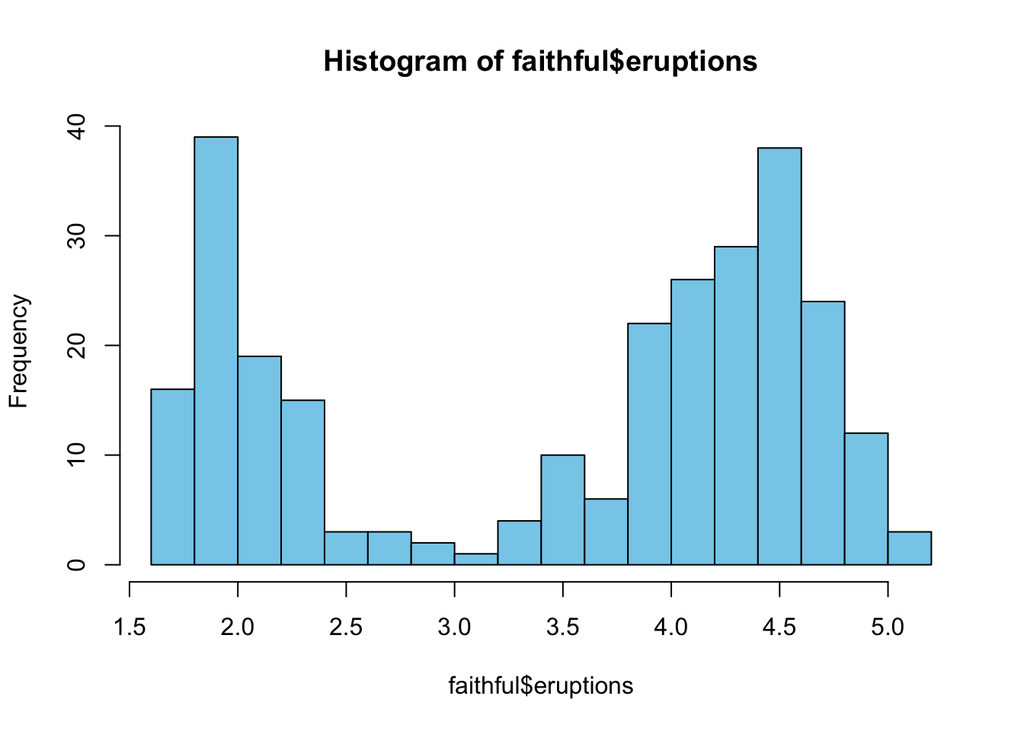

```
## [1] 4
```

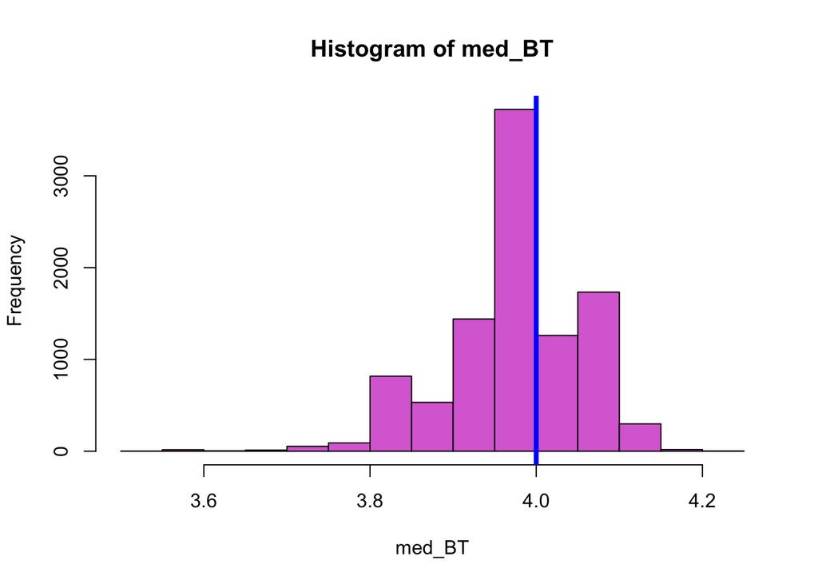

```
## [1] 0.006486148
```

The command `w = sample(n,n, replace=T)` generates indices that are IID from a uniform distribution over $1,2,3, ..., n$. Thus, the command `faithful$eruptions[w]` selects those observations being selected and it is then a sample with replacement from the original data `faithful$eruptions`.

Moreover, because we know that the sample median (under suitable conditions) follows roughly a Normal distribution. We can then construct a $90\%$ confidence interval using

```
## [1] 4.132471
```

```
## [1] 3.867529
```

The bootstrap can also be applied to estimate the uncertainty of a statistic of values of two variables such as the *sample correlation*. Here is one example using the `faithful` data again.

```
##           eruptions   waiting
## eruptions 1.0000000 0.9008112
## waiting   0.9008112 1.0000000
```

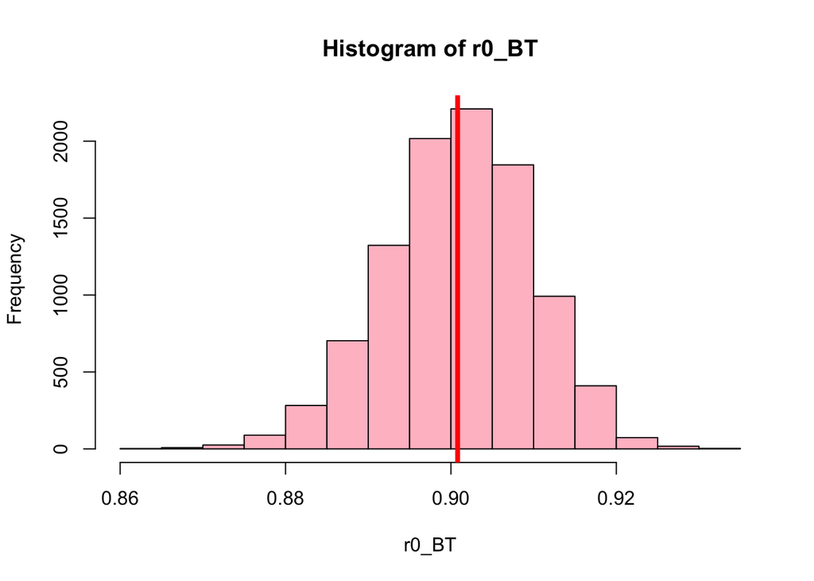

```
## [1] 7.771569e-05
```

```
## [1] 0.9153116
```

```
## [1] 0.8863107
```

The bootstrap can also be applied to estimate the uncertainty of a density estimator. Here we will illustrate this by the KDE of variable `eruptions` in the `faithful` dataset.

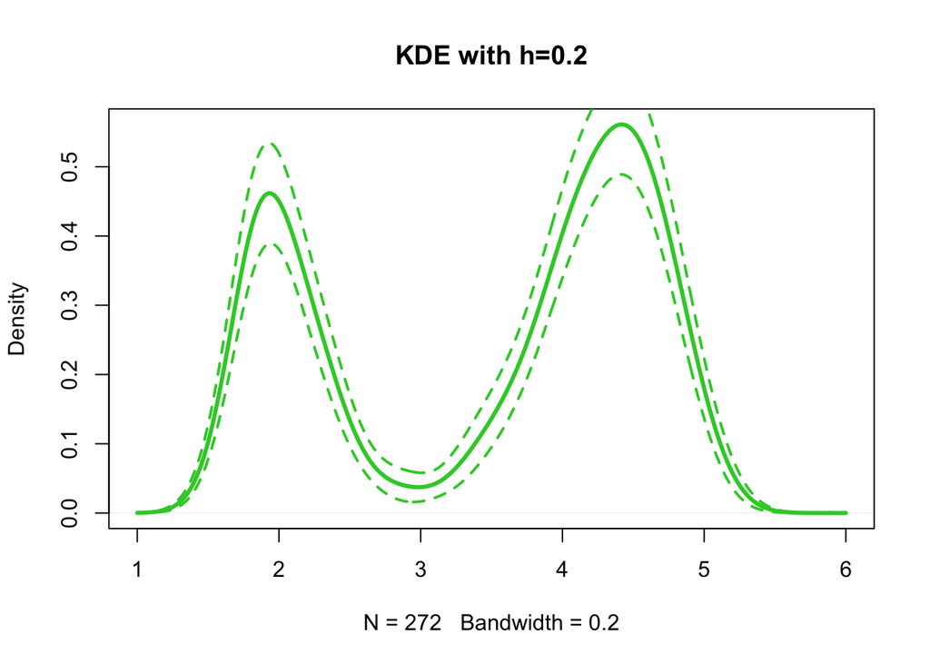

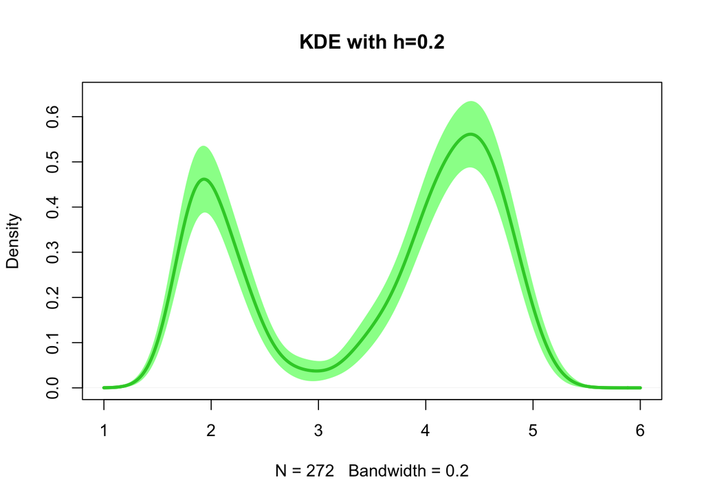

### Exercise - 2

Now we will consider the dataset `iris`.

1. We focus on the variable `Sepal.Length`.
   - What is the sample SD of this variable?
   - Use the bootstrap to show the distribution of the sample SD.
   - What is the variance of the sample SD computed using the bootstrap?
   - Find a 90% CI of the sample SD.
2. We focus on two variables `Sepal.Length` and `Sepal.Width`. And we want to analyze the correlation between them.
   - What is the sample correlation?
   - Use the bootstrap to show the distribution of the sample correlation
   - What is the variance of the sample correlation computed using the bootstrap?
   - Find a 90% CI of the sample correlation.